# Week 3 Peer Review

Following the directions on the Coursera assignment page, you will make four original visualizations. Note that the data for the CCES and CEL data are imported in code in the R Markdown file.

### Put your name here: Tamoghna Santra

## Exercise 1

Explain what you are visualizing here:

This is a Scatter Plot representing,

Percentage of votes (votepct) in x-axis. Number if bills transformed into law (all_law) in y-axis The graph is facetted into different each congress which changes every 2 years The ratio of the gender representing the congress each time is also represented by the 2 given colours

This analysis shows how the number of bills transformed into law has occured in different congresses with the informations of their sex ratio of representatives and vote percentages the MC won in the elections.

Put your figure here:

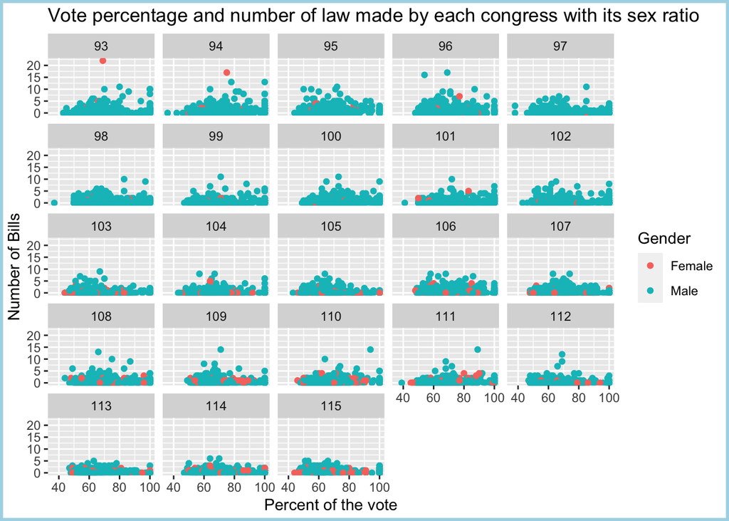

## Exercise 2

Explain what you are visualizing here:

This is a Bar Plot representing,

Number of representatives in x-axis. Education Standard in y-axis The graph is showing the different set of representatives in different colour in the bar plot which represents how diverse are the students in different standards of education

Put your figure here:

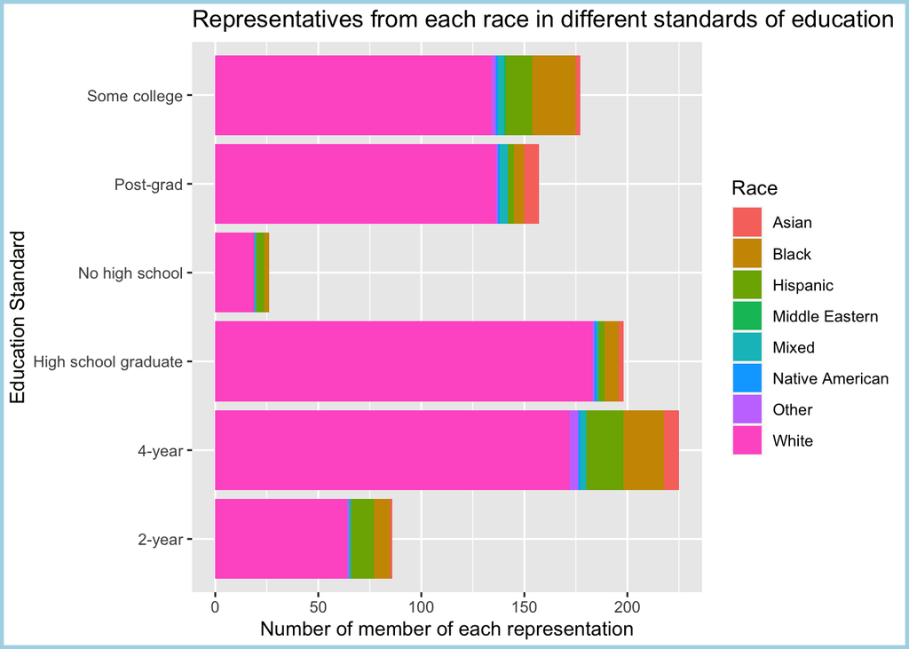

## Exercise 3

Explain what you are visualizing here:

Put your figure here:

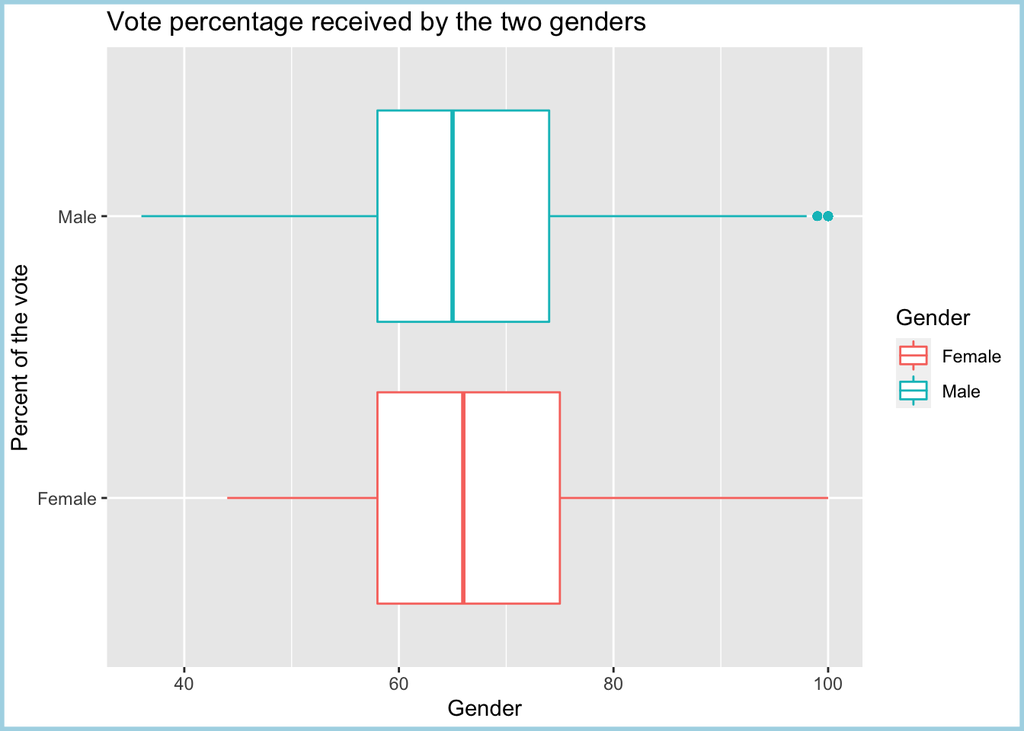

## Exercise 4

Explain what you are visualizing here:

Put your figure here:

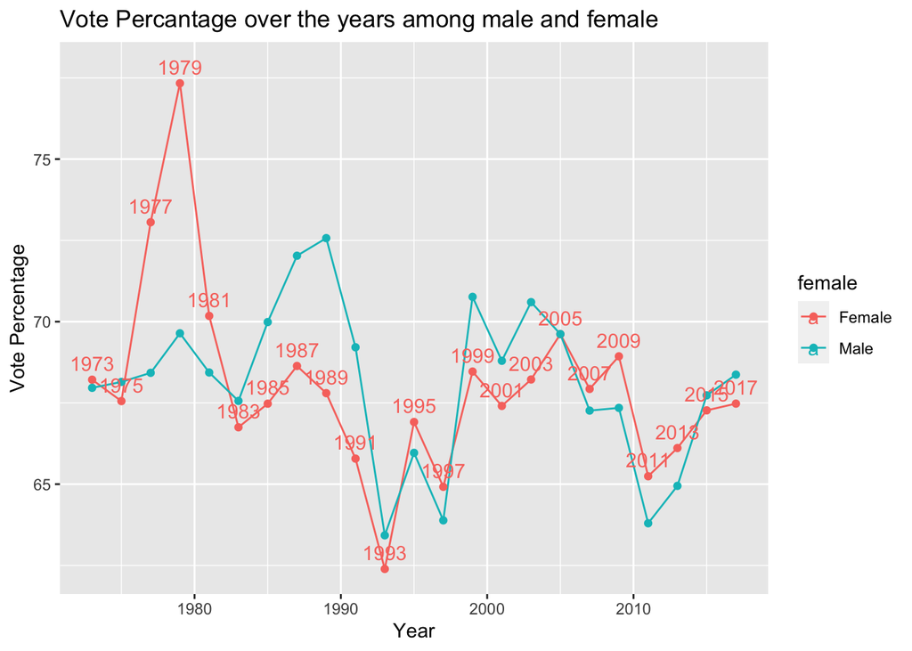